# Take Home

Dominik Peter

5 1 2017

# Lösung zu Take Home Aufgaben

## Ebay

```r
df_ebay <- read.dta("http://www.farys.org/daten/ebay.dta") %>%
  as.data.table(.)
```

- sold: Ob das Mobiltelefon verkauft wurde
- price: Der erzielte Verkauftspreis
- sprice: Der Startpreis der Auktion
- sepos: Anzahl positiver Bewertungen des Verkäufers
- seneg: Anzahl negativer Bewertungen des Verkäufers
- subcat: Das Modell des Mobiltelefons
- listpic: Kategorialer Indikator, ob die Auktion ein Thumbnail, ein “has-picture-icon” oder kein Thumbnail hat.
- listbold: Dummy, ob die Auktion fettgedruckt gelistet ist
- sehasme: Dummy, ob der Verkäufer eine “Me-page” hat oder nicht

```r
# Data Wrangling
df_ebay <- df_ebay[, rating := sepos/rowSums(.SD), .SDcols = c("sepos", "seneg")]
df_ebay <- df_ebay[, `:=` (makellos = factor(rating > .98, levels = c(TRUE, FALSE),
                                             labels = c("Ja", "Nein")),
                           cat = str_replace(subcat, "\\ \\(\\d+\\)", ""))]
# Variablenzuteilung ist redundant, jedoch wird so die data.table Tabelle in Markdown nicht evaluiert

df_ebay_final <- df_ebay[sepos > 11, !"subcat"]

set.seed(2323) #wegen Sampling

df_ebay_final %>%
  sample(replace = FALSE) %>%
  head(3) %>%
  pander(.)
```

Table continues below

| makellos | cat | price | rating | listbold | sepos | sold | seneg |
| --- | --- | --- | --- | --- | --- | --- | --- |
| Ja | Nokia 6230 | 221 | 0.9867 | 0 | 372 | 1 | 5 |
| Ja | Samsung E700 | 211 | 1 | 0 | 153 | 1 | 0 |
| Ja | Motorola V600 | 221 | 1 | 0 | 20 | 1 | 0 |

| listpic | sprice | sehasme |
| --- | --- | --- |
| auction-has-picture icon | 1 | 0 |
| thumbnail | 1 | 0 |
| auction-has-picture icon | 200 | 0 |

### Plotting

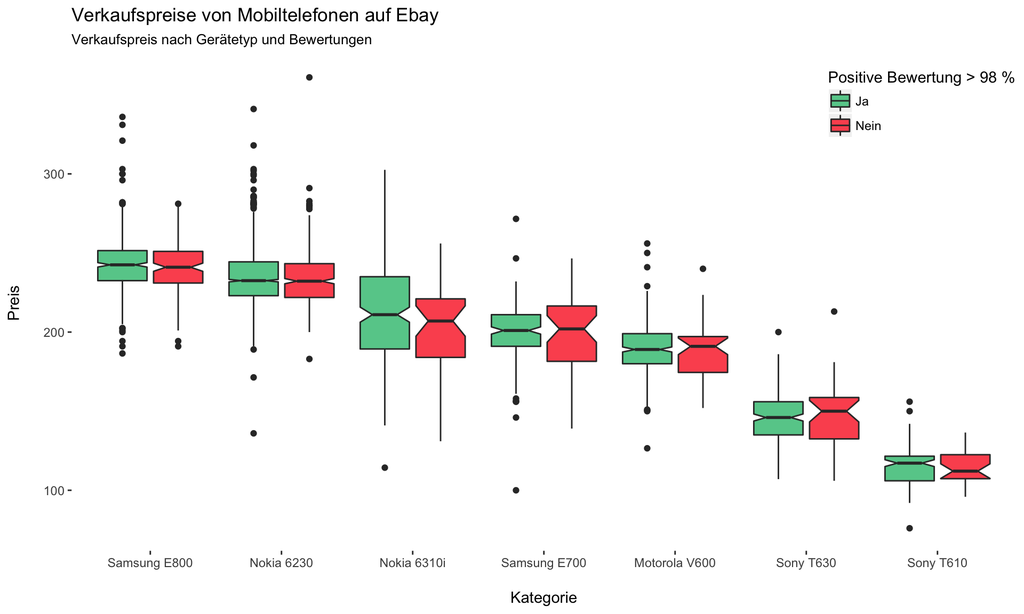

```r
# Es gibt Preise mit NA (nicht verkauft), daher funktioniert der Reorder nicht
# ohne anonyme Funktion mit na.rm = TRUE möglich
# Absteigende Anordung mit -1
gplot <- df_ebay_final %>%
  ggplot(aes(x=reorder(factor(cat), price, function(x) mean(x, na.rm = TRUE)*-1), y = price)) +
  geom_boxplot(aes(fill = makellos), notch = TRUE, position = position_dodge(.85)) +
  scale_fill_manual(values = c("#66CC99", "#FC575E"), name = "Positive Bewertung > 98 %") +
  xlab("\nKategorie") +
  ylab("Preis\n") +
  ggtitle("Verkaufspreise von Mobiltelefonen auf Ebay",
          subtitle = "Verkaufspreis nach Gerätetyp und Bewertungen") +
  theme(panel.background = element_blank(),#element_rect(fill = "#F0F1F5"),
        panel.grid.major = element_line(color = "white", size = 1.1),
        panel.grid.minor = element_blank(),
        legend.position = c(.9, .9))

gplot
```

#### Exportieren

Exportieren mit der ggplot2 Funktion ggsave()

```r
ggsave("plot_export.pdf", plot = gplot, width = 10, height = 6)
```

Bewertet anhand “Rule of Thumb”, dass bei signifikanter Differenz die Notches nicht überlappen sollten.  
Daher die Feststellung, dass kein signifikanter Unterschied zwischen den makellosen und nicht makellosen Ratings besteht.  
https://en.wikipedia.org/wiki/Box_plot#Variations

### Regression

Rechnen Sie zwei kleine Regressionsmodelle für den Preis von verkauften Geräten. Modell 1 soll als Prädiktoren den Modelltyp und das Rating beinhalten. Modell 2 soll zusätzlich die Variable listpic beinhalten. Haben das Rating und die Thumbnails einen Einfluss auf den Verkaufspreis? Exportieren Sie eine Regressionstabelle, die beide Modelle beinhaltet.

```r
model_1 <- lm(price ~ cat + rating, data = df_ebay_final)
summary(model_1)
```

```
##
## Call:
## lm(formula = price ~ cat + rating, data = df_ebay_final)
##
## Residuals:
##     Min      1Q  Median      3Q     Max
## -98.782 -11.042  -0.104  10.557 127.396
##
## Coefficients:
##                 Estimate Std. Error t value Pr(>|t|)
## (Intercept)     166.3811    12.9666  12.832  < 2e-16 ***
## catNokia 6230    45.7591     0.9993  45.791  < 2e-16 ***
## catNokia 6310i   20.8931     1.4551  14.359  < 2e-16 ***
## catSamsung E700  10.8761     1.5211   7.150 1.02e-12 ***
## catSamsung E800  54.2788     1.1892  45.641  < 2e-16 ***
## catSony T610    -72.2618     1.7420 -41.482  < 2e-16 ***
## catSony T630    -42.4089     1.4671 -28.907  < 2e-16 ***
## rating           21.9020    13.0252   1.682   0.0927 .
## ---
## Signif. codes:  0 '***' 0.001 '**' 0.01 '*' 0.05 '.' 0.1 ' ' 1
##
## Residual standard error: 18.45 on 4208 degrees of freedom
##   (155 observations deleted due to missingness)
## Multiple R-squared:  0.754,  Adjusted R-squared:  0.7535
## F-statistic:  1842 on 7 and 4208 DF,  p-value: < 2.2e-16
```

```r
model_2 <- lm(price ~ cat + rating + listpic, data = df_ebay_final)
summary(model_2)
```

```
##
## Call:
## lm(formula = price ~ cat + rating + listpic, data = df_ebay_final)
##
## Residuals:
##      Min       1Q   Median       3Q      Max
## -100.392  -10.946   -0.231   10.649  125.909
##
## Coefficients:
##                                 Estimate Std. Error t value Pr(>|t|)
## (Intercept)                     163.8373    12.9706  12.631  < 2e-16 ***
## catNokia 6230                    45.5946     0.9975  45.711  < 2e-16 ***
## catNokia 6310i                   20.7111     1.4516  14.268  < 2e-16 ***
## catSamsung E700                  10.8426     1.5167   7.149 1.03e-12 ***
## catSamsung E800                  54.1327     1.1883  45.556  < 2e-16 ***
## catSony T610                    -72.1244     1.7364 -41.536  < 2e-16 ***
## catSony T630                    -42.6107     1.4633 -29.121  < 2e-16 ***
## rating                           19.3225    12.9913   1.487  0.13700
## listpicauction-has-picture icon   4.3895     1.4903   2.945  0.00324 **
## listpicthumbnail                  6.7229     1.5011   4.479 7.71e-06 ***
## ---
## Signif. codes:  0 '***' 0.001 '**' 0.01 '*' 0.05 '.' 0.1 ' ' 1
##
## Residual standard error: 18.39 on 4206 degrees of freedom
##   (155 observations deleted due to missingness)
## Multiple R-squared:  0.7557, Adjusted R-squared:  0.7552
## F-statistic:  1445 on 9 and 4206 DF,  p-value: < 2.2e-16
```

##### Interpretation

Die Thumbnails haben mit einem P-Value ~ 7.7e-06 einen signifikanten Einfluss auf den Preis.  
Mit einem Koeffizienten von 6.72 steigt der Preis, gegenüber dem Factor “none” um diesen Wert.

#### Exportieren

Exportieren des Regressionsmodells mit Hilfe von Stargazer

```r
stargazer(model_1, model_2,
          type = "html",
          covariate.labels = c("Nokia 6230","Nokia 6310i", "Samsung E700", "Samsung E800",
                               "Sony T610", "Sony T630", "rating", "auction-has-picture",
                               "auction-has-thumbnail"))
```

|  | *Dependent variable:* |  |
| --- | --- | --- |
|  | price |  |
|  | (1) | (2) |
| Nokia 6230 | 45.759*** | 45.595*** |
|  | (0.999) | (0.997) |
| Nokia 6310i | 20.893*** | 20.711*** |
|  | (1.455) | (1.452) |
| Samsung E700 | 10.876*** | 10.843*** |
|  | (1.521) | (1.517) |
| Samsung E800 | 54.279*** | 54.133*** |
|  | (1.189) | (1.188) |
| Sony T610 | -72.262*** | -72.124*** |
|  | (1.742) | (1.736) |
| Sony T630 | -42.409*** | -42.611*** |
|  | (1.467) | (1.463) |
| rating | 21.902* | 19.322 |
|  | (13.025) | (12.991) |
| auction-has-picture |  | 4.390*** |
|  |  | (1.490) |
| auction-has-thumbnail |  | 6.723*** |
|  |  | (1.501) |
| Constant | 166.381*** | 163.837*** |
|  | (12.967) | (12.971) |
| Observations | 4,216 | 4,216 |
| R<sup>2</sup> | 0.754 | 0.756 |
| Adjusted R<sup>2</sup> | 0.754 | 0.755 |
| Residual Std. Error | 18.451 (df = 4208) | 18.391 (df = 4206) |
| F Statistic | 1,842.068*** (df = 7; 4208) | 1,445.500*** (df = 9; 4206) |
| *Note:* | p<0.1; p<0.05; p<0.01 |  |

## Webscraping

### Extrahieren der Tabelle aus Wikipedia

```r
url <- 'https://de.wikipedia.org/wiki/Bern'

#laden une bereinigen
df_web <- url %>%
  read_html(.) %>%
  html_table(fill = TRUE, header = TRUE) %>%
  .[[6]] %>%
  na.omit(.) %>%
  as.data.table(.) %>%
  .[, 1:13, with = FALSE]

setnames(df_web, 1, "typ")
```

### Transformation und Bereinigung der Daten

```r
# convert value to numeric and eliminate NA columns
to_numeric <- function(x) {
  x <- str_replace_all(x, ",", "\\.")
  as.numeric(x)
}

months <-  colnames(df_web)[-1]
# apply function
df_web[, months] <- lapply(df_web[, months, with = FALSE], to_numeric)

df_web_tidy <- df_web[1:3] %>%
  melt(id.vars = "typ", variable.name = "Monat") %>%
  dcast(Monat ~ typ)

col_names <- colnames(df_web_tidy)
setnames(df_web_tidy, col_names, c(col_names[1], c("Max", "Min", "Mittelwert")))
```

### Exportieren

Exportieren als Pandoc Objekt

```r
df_web_output <- copy(df_web_tidy) #Kopieren, da ich die Zahlen in Strings umwandle

df_web_output <- df_web_output[, `:=` (Max = format(round(Max, 3), nsmall = 3),
                                       Min = format(round(Min, 3), nsmall = 3))][, .(Monat, Max, Min)]
df_web_output %>% pander()
```

| Monat | Max | Min |
| --- | --- | --- |
| Jan | 2.800 | -3.600 |
| Feb | 4.700 | -3.100 |
| Mär | 9.500 | 0.200 |
| Apr | 13.400 | 3.000 |
| Mai | 18.200 | 7.400 |
| Jun | 21.600 | 10.500 |
| Jul | 24.300 | 12.500 |
| Aug | 23.700 | 12.300 |
| Sep | 19.100 | 8.900 |
| Okt | 13.800 | 5.400 |
| Nov | 7.300 | 0.400 |
| Dez | 3.500 | -2.300 |

Die Ausgabe des Objekts mit Stargazer

```r
stargazer(df_web_output, type = "html", summary = FALSE)
```

|  | Monat | Max | Min |
| --- | --- | --- | --- |
| 1 | Jan | 2.800 | -3.600 |
| 2 | Feb | 4.700 | -3.100 |
| 3 | Mär | 9.500 | 0.200 |
| 4 | Apr | 13.400 | 3.000 |
| 5 | Mai | 18.200 | 7.400 |
| 6 | Jun | 21.600 | 10.500 |
| 7 | Jul | 24.300 | 12.500 |
| 8 | Aug | 23.700 | 12.300 |
| 9 | Sep | 19.100 | 8.900 |
| 10 | Okt | 13.800 | 5.400 |
| 11 | Nov | 7.300 | 0.400 |
| 12 | Dez | 3.500 | -2.300 |

Im Aufgabenbeispiel haben alle Werte 3 Dezimalstellen, bis auf die 3 im April -dies wäre sicherlich umsetzbar. Ich habe mich jedoch dagegen entschieden, da so jetzt alle Werte 3 Dezimalstellen aufweisen.

### Grafische Darstellung

#### Nicht Teil der Aufgabenstellung

Just for Fun

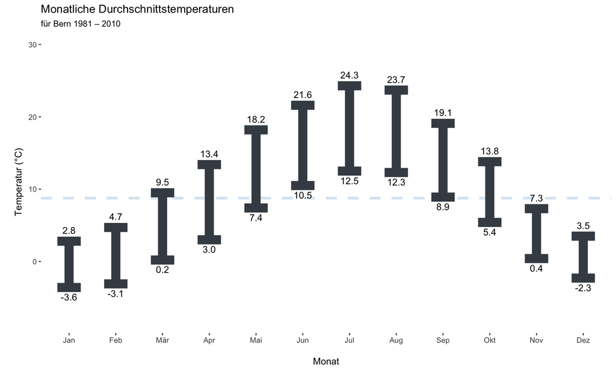

```r
mean_temp <- mean(df_web_tidy$Mittelwert)
min <- scales::comma(df_web_tidy$Min)
max <- scales::comma(df_web_tidy$Max)

df_web_tidy  %>%
  ggplot(aes(x = Monat, y = Mittelwert)) +
  geom_point(size = 1.5, color = "#444B54") +
  geom_hline(yintercept = mean_temp, color = "#2980B9", size = 1.5, alpha = 0.2, linetype = 2) +
  geom_errorbar(aes(ymin = Min, ymax = Max), width = .5, color = "#444B54", size = 5) +
  ylab("\nTemperatur (°C)") +
  xlab("\nMonat") +
  geom_text(aes(y=Min), label = min, vjust = 1.9) +
  geom_text(aes(y=Max), label = max, vjust = -1.1) +
  ylim(-8, 30) +
  ggtitle("Monatliche Durchschnittstemperaturen", subtitle = "für Bern 1981 – 2010") +
  theme(panel.background = element_blank(),
        # panel.grid.major = element_line(color = "#F0F1F5", size = 0.2),
        panel.grid.minor = element_blank()
        )
```